# Internet Adoption

Krisztian Szavuly

2017 february 2

## Introduction

Access to information is an important prerequisite for making decisions, leading to the question of countries’ capabilities in the digital age. Therefore we ask the question of how the performance of countries relates to their internet adoption; performance being defined by gross domestic product (GDP) per capita and readiness by number of internet users per 100 people. In our paper we first examine the relationship between the two, then elaborate on whether is the question a causal one and in which way.

## Description of the Data

We sourced data from the World Bank’s World Development Indicators website, downloaded on 12.27.2016. Our dataset contained Internet users (per 100 people), Secure Internet servers, Fixed telephone subscriptions, Fixed telephone subscriptions (per 100 people), Mobile cellular subscriptions (per 100 people) and GDP per capita (constant 2010 US$)* [full descriptions are available in the Appendix] from 1960 to 2016. For the analysis, we ended up using the observations marked with asterisks, until 2015 where data was available.

## Transformations in the Dataset

```r
# SUBSETTING AND COMBINING SERIES
internet <- subset(dataset, select = c("country", "2015"), series == "Internet users (per 100 people)")
names(internet)[names(internet) == "2015"] <- "internet"
internet$internet <- as.numeric(as.character(internet$internet))
landline <- subset(dataset, select = c("country", "2015"), series == "Fixed telephone subscriptions (per 100 people)")
names(landline)[names(landline) == "2015"] <- "landline"
landline$landline <- as.numeric(as.character(landline$landline))
mobile <- subset(dataset, select = c("country", "2015"), series == "Mobile cellular subscriptions (per 100 people)")
names(mobile)[names(mobile) == "2015"] <- "mobile"
mobile$mobile <- as.numeric(as.character(mobile$mobile))
gdppc <- subset(dataset, select = c("country", "2015"), series == "GDP per capita (constant 2010 US$)")
names(gdppc)[names(gdppc) == "2015"] <- "gdppc"
gdppc$gdppc <- as.numeric(as.character(gdppc$gdppc))
gdppc$lngdppc <- log(gdppc$gdppc)
telco <- merge(gdppc,internet,by="country")
telco <- merge(telco,landline,by="country")
telco <- merge(telco,mobile,by="country")
telco$gdppc <- NULL

# SUMMARY AND FINALIZATION OF THE DATASET
summary(telco)
```

```
##            country       lngdppc          internet         landline
##  Afghanistan   :  1   Min.   : 5.331   Min.   : 1.084   Min.   :  0.000
##  Albania       :  1   1st Qu.: 7.415   1st Qu.:21.932   1st Qu.:  2.893
##  Algeria       :  1   Median : 8.612   Median :46.886   Median : 13.331
##  American Samoa:  1   Mean   : 8.576   Mean   :47.559   Mean   : 17.581
##  Andorra       :  1   3rd Qu.: 9.576   3rd Qu.:71.462   3rd Qu.: 25.172
##  Angola        :  1   Max.   :11.575   Max.   :98.324   Max.   :128.092
##  (Other)       :258   NA's   :37       NA's   :16       NA's   :9
##      mobile
##  Min.   :  7.05
##  1st Qu.: 80.38
##  Median :107.81
##  Mean   :106.23
##  3rd Qu.:128.08
##  Max.   :324.44
##  NA's   :14
```

```r
telco <- telco[complete.cases(telco),]
summary(telco)
```

```
##                 country       lngdppc          internet
##  Afghanistan        :  1   Min.   : 5.331   Min.   : 2.22
##  Albania            :  1   1st Qu.: 7.414   1st Qu.:21.84
##  Algeria            :  1   Median : 8.618   Median :45.98
##  Angola             :  1   Mean   : 8.576   Mean   :46.83
##  Antigua and Barbuda:  1   3rd Qu.: 9.590   3rd Qu.:70.24
##  Arab World         :  1   Max.   :11.575   Max.   :98.20
##  (Other)            :216
##     landline          mobile
##  Min.   : 0.000   Min.   : 20.45
##  1st Qu.: 2.234   1st Qu.: 80.65
##  Median :11.800   Median :109.71
##  Mean   :15.846   Mean   :108.32
##  3rd Qu.:22.569   3rd Qu.:129.26
##  Max.   :59.907   Max.   :324.44
##
```

## First impressions of the Series

Four histograms were built to have a first impression of the series we will be dealing with. We took the natural log of GDP per capita, which presented us a histogram with a very symmetric distribution.

The density of internet users is also symmetric but shows specificities. With a bin width of 10 for internet users per 100 people we can spot that penetrations are either under 25%, around 40% or over 70%.

Landline penetration is skewed to the right, with not much countries having more than 20%. Mobile subscriptions are difficult to measure with data at the highest density over 100% with more subscription than one per people [see Appendix for description].

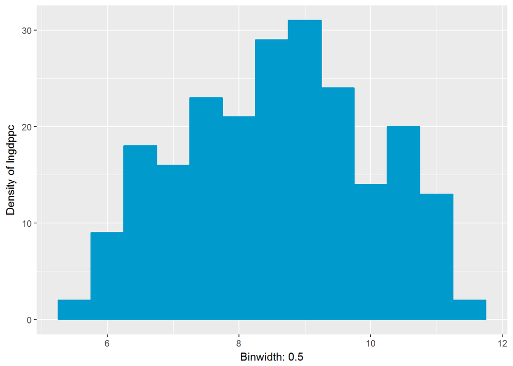

```r
# HISTOGRAMS
ggplot(telco, aes(x = lngdppc)) + geom_histogram(stat = "bin", binwidth=0.5, fill="deepskyblue3", colour="deepskyblue3") +labs(x="Binwidth: 0.5", y="Density of lngdppc")
```

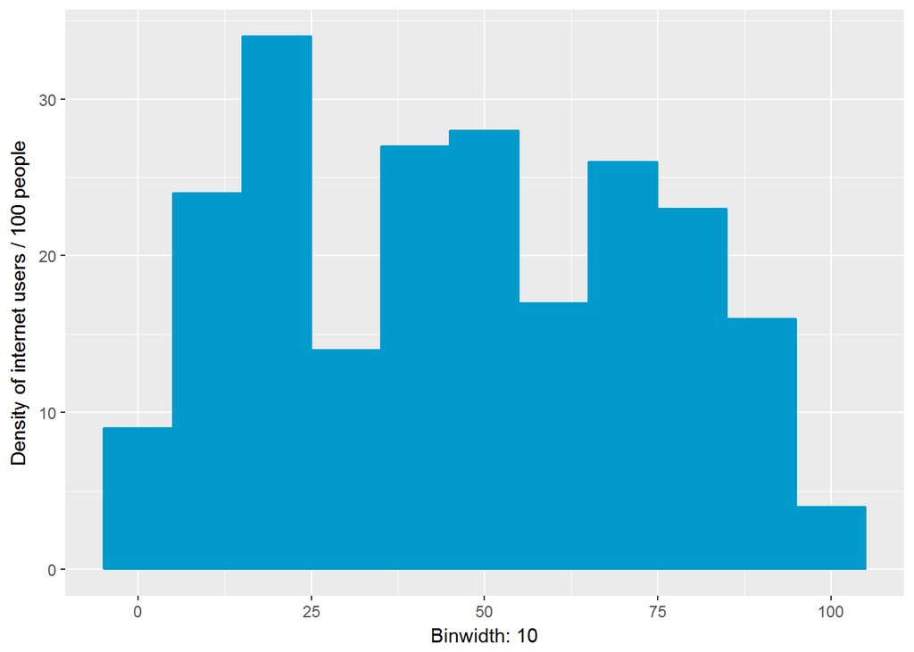

```r
ggplot(telco, aes(x = internet)) + geom_histogram(stat = "bin", binwidth=10, fill="deepskyblue3", colour="deepskyblue3") +labs(x="Binwidth: 10", y="Density of internet users / 100 people")
```

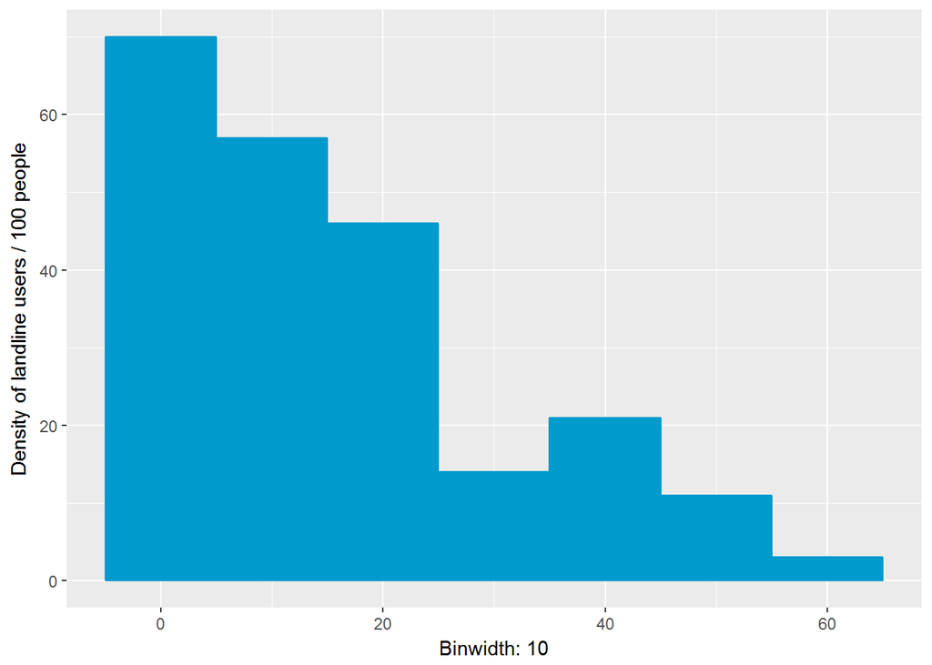

```r
ggplot(telco, aes(x = landline)) + geom_histogram(stat = "bin", binwidth=10, fill="deepskyblue3", colour="deepskyblue3") +labs(x="Binwidth: 10", y="Density of landline users / 100 people")
```

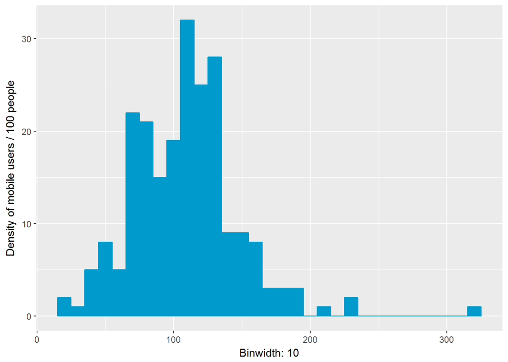

```r
ggplot(telco, aes(x = mobile)) + geom_histogram(stat = "bin", binwidth=10, fill="deepskyblue3", colour="deepskyblue3") +labs(x="Binwidth: 10", y="Density of mobile users / 100 people")
```

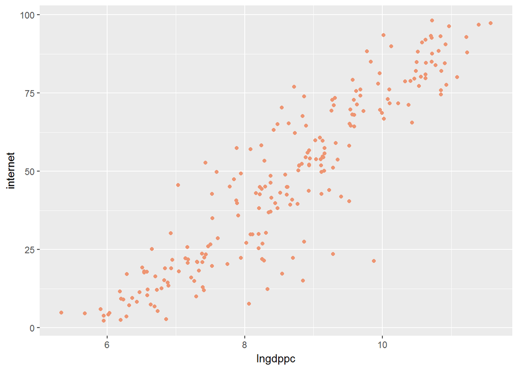

```r
# SCATTERPLOTS
ggplot(data = telco, aes(x=lngdppc, y=internet)) + geom_point(size=1.5, colour="lightsalmon2")
```

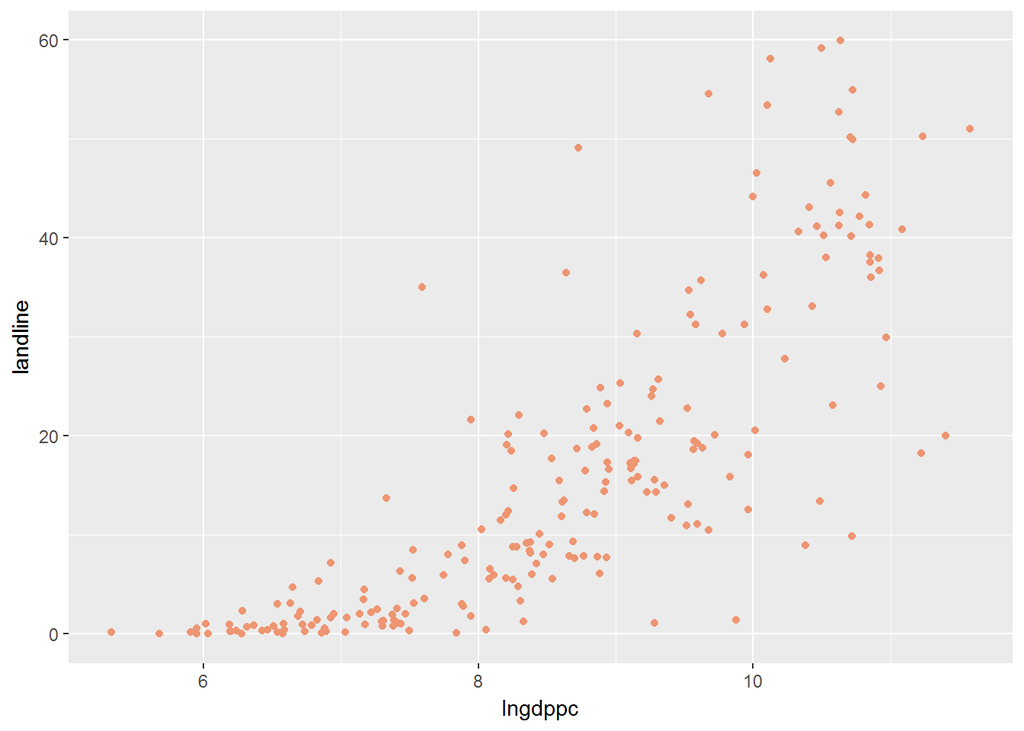

```r
ggplot(data = telco, aes(x=lngdppc, y=landline)) + geom_point(size=1.5, colour="lightsalmon2")
```

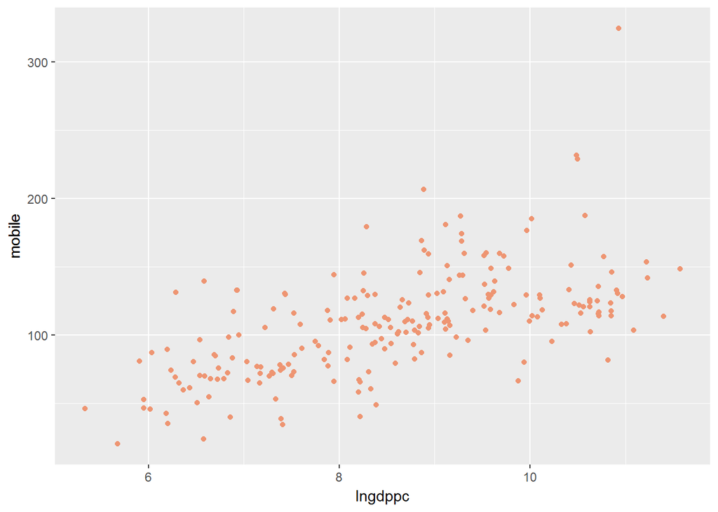

```r
ggplot(data = telco, aes(x=lngdppc, y=mobile)) + geom_point(size=1.5, colour="lightsalmon2")
```

## First Findings

The first thing we see when scatterplotting the data points of internet users per 100 people (internet) with the natural log of GDP per capita (lngdppc) is how equally they are following linearity, although with a quite large amount of residuals. Here is the scatterplot shown with a lowess regression with standard error:

When taking a closer look at the residuals of the regression, its skewness is -0.61, with a minimum of -47.91 and a maximum of only 27.70: countries, that are lagging behind are doing so more severely.

Stacking lowess, linear and quadratic regressions on the same chart shows very strong similarity, pointing us towards the linear regression.

The regressions differ more under 0 internet, but we don’t interpret this, as there is no negative internet penetration. They also differ above 90 internet, but there aren’t much data points above this threshold and we are safe to say, that digital communication capabilities between 90% and 100% internet penetration are quite similar.

## A Positive Relationship

The positive relationship between lngdppc and internet-penetration is beyond doubt: countries with 10% more GDP are expected to have 1.72 more internet user per 100 people on average, with a confidence interval of 1.06 (so between 1.62 and 1.83 more).

Two other variables are related to telecommunications: landline and mobile subscriptions. When using these are control variables, we can make the following three statements:

Controlling for landline and/or mobile added 0 or only 0.02 and 0.03 to our R-squared, but internet-penetration regression’s coefficient seems to be similar to mobile’s.

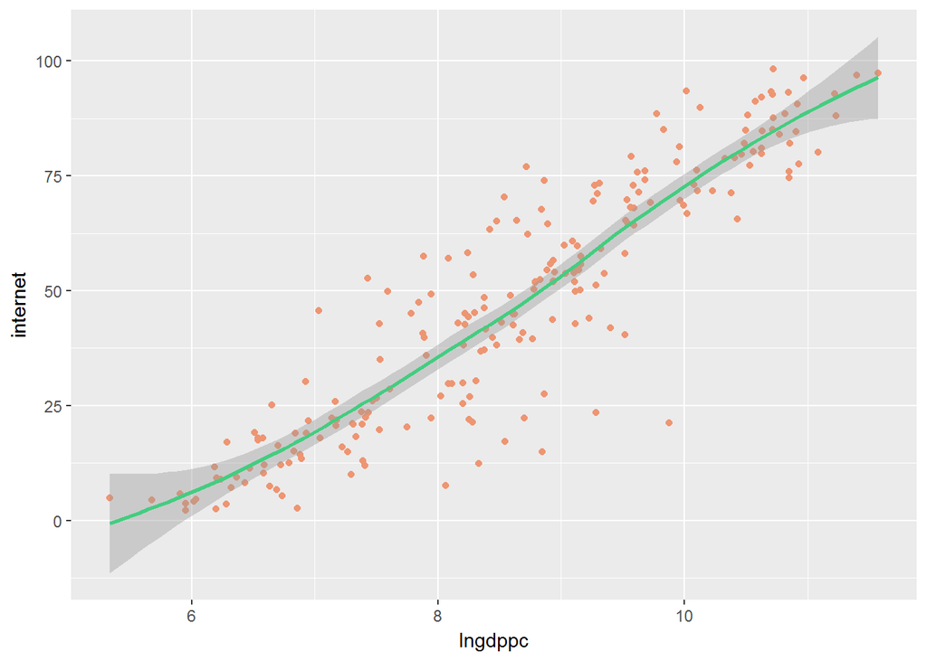

```r
# PLOTTING REGRESSIONS ON INTERNET
ggplot(data = telco, aes(x=lngdppc, y=internet)) +
  geom_point(size=1.5, colour="lightsalmon2") +
  geom_smooth(method="loess", colour="seagreen3", se=T)
```

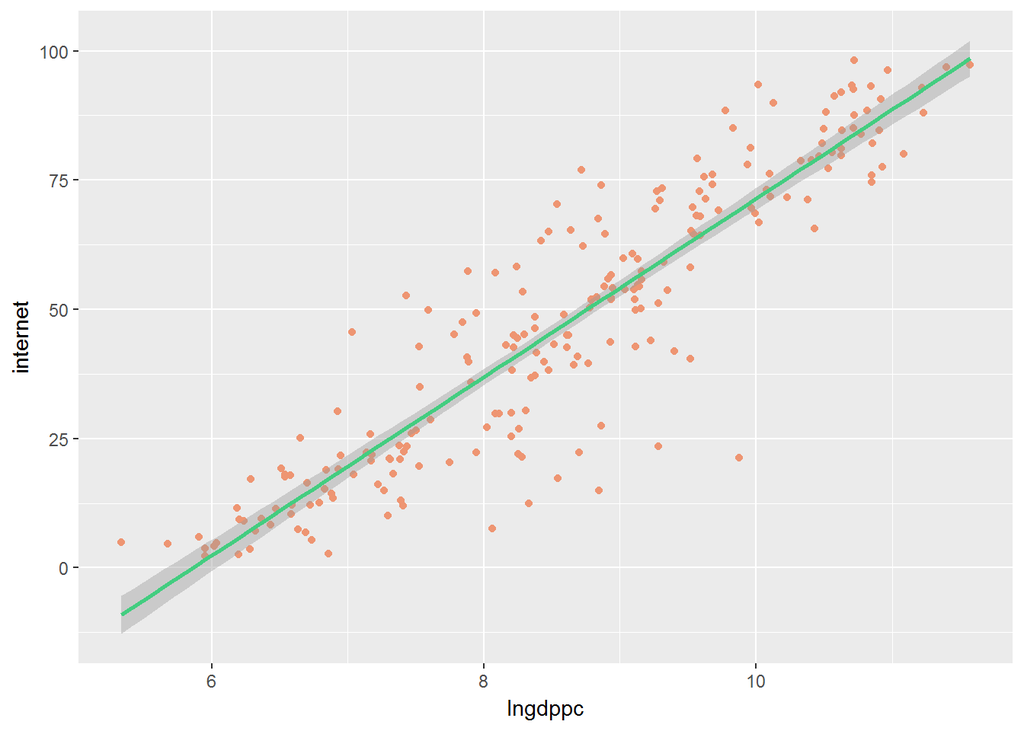

```r
ggplot(data = telco, aes(x=lngdppc, y=internet)) +
  geom_point(size=1.5, colour="lightsalmon2") +
  geom_smooth(method="lm", colour="seagreen3", se=T)
```

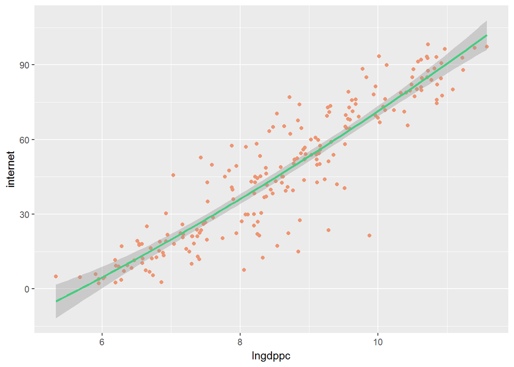

```r
ggplot(data = telco, aes(x=lngdppc, y=internet)) +
  geom_point(size=1.5, colour="lightsalmon2") +
  geom_smooth(method="lm", formula=y~poly(x,2,raw = TRUE), colour="seagreen3", se=T)
```

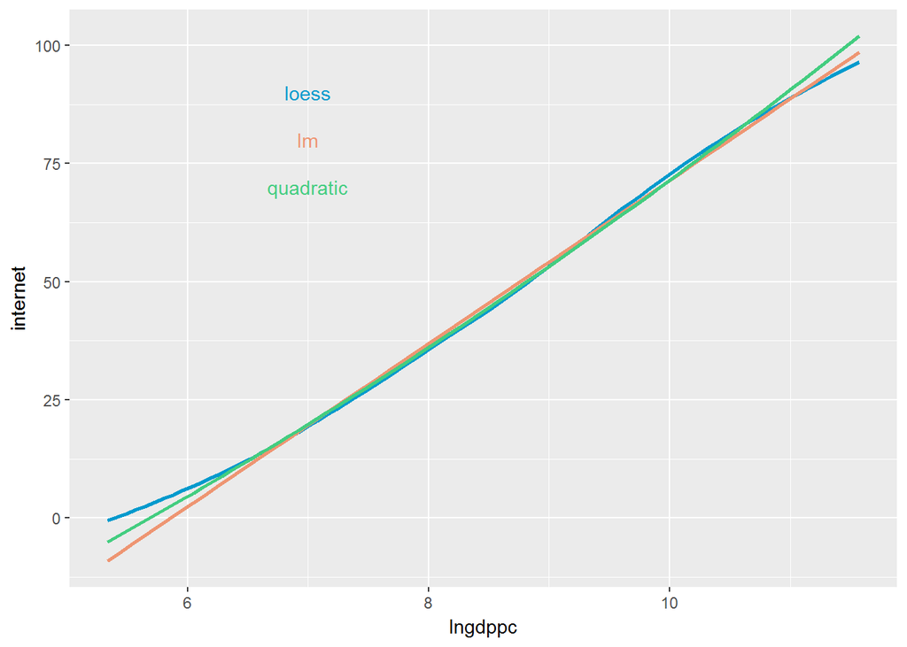

```r
ggplot(telco) +
  geom_smooth(aes(lngdppc, internet), method = "loess", colour = "deepskyblue3", se=F) +
  annotate("text", x = 7, y = 90, label = "loess", colour = "deepskyblue3") +
  geom_smooth(aes(lngdppc, internet), method = "lm", colour = "lightsalmon2", se=F) +
  annotate("text", x = 7, y = 80, label = "lm", colour = "lightsalmon2") +
  geom_smooth(aes(lngdppc, internet), method = "lm", formula=y~poly(x,2,raw = TRUE), colour = "seagreen3", se=F) +
  annotate("text", x = 7, y = 70, label = "quadratic", colour = "seagreen3")
```

```r
# REGRESSIONS ON INTERNET WITH CONTROLS
reg1 <- lm(internet ~ lngdppc, data = telco)
reg2 <- lm(internet ~ lngdppc + landline, data = telco)
reg3 <- lm(internet ~ lngdppc + mobile, data = telco)
reg4 <- lm(internet ~ lngdppc + landline + mobile, data = telco)
stargazer(list(reg1, reg2, reg3, reg4), digits = 2, out = "regressions_internet_1.html")
```

```
##
## % Table created by stargazer v.5.2 by Marek Hlavac, Harvard University. E-mail: hlavac at fas.harvard.edu
## % Date and time: Cs, febr. 02, 2017 - 21:44:20
## \begin{table}[!htbp] \centering
##   \caption{}
##   \label{}
## \begin{tabular}{@{\extracolsep{5pt}}lcccc}
## \\[-1.8ex]\hline
## \hline \\[-1.8ex]
##  & \multicolumn{4}{c}{\textit{Dependent variable:}} \\
## \cline{2-5}
## \\[-1.8ex] & \multicolumn{4}{c}{internet} \\
## \\[-1.8ex] & (1) & (2) & (3) & (4)\\
## \hline \\[-1.8ex]
##  lngdppc & 17.25$^{***}$ & 13.32$^{***}$ & 16.63$^{***}$ & 12.22$^{***}$ \\
##   & (0.53) & (0.81) & (0.66) & (0.92) \\
##   & & & & \\
##  landline &  & 0.45$^{***}$ &  & 0.48$^{***}$ \\
##   &  & (0.08) &  & (0.08) \\
##   & & & & \\
##  mobile &  &  & 0.04 & 0.05$^{**}$ \\
##   &  &  & (0.02) & (0.02) \\
##   & & & & \\
##  Constant & $-$101.08$^{***}$ & $-$74.64$^{***}$ & $-$99.84$^{***}$ & $-$71.51$^{***}$ \\
##   & (4.57) & (6.10) & (4.62) & (6.17) \\
##   & & & & \\
## \hline \\[-1.8ex]
## Observations & 222 & 222 & 222 & 222 \\
## R$^{2}$ & 0.83 & 0.85 & 0.83 & 0.86 \\
## Adjusted R$^{2}$ & 0.83 & 0.85 & 0.83 & 0.86 \\
## Residual Std. Error & 11.17 (df = 220) & 10.37 (df = 219) & 11.14 (df = 219) & 10.26 (df = 218) \\
## F Statistic & 1,078.82$^{***}$ (df = 1; 220) & 644.15$^{***}$ (df = 2; 219) & 543.85$^{***}$ (df = 2; 219) & 441.00$^{***}$ (df = 3; 218) \\
## \hline
## \hline \\[-1.8ex]
## \textit{Note:}  & \multicolumn{4}{r}{$^{*}$p$<$0.1; $^{**}$p$<$0.05; $^{***}$p$<$0.01} \\
## \end{tabular}
## \end{table}
```

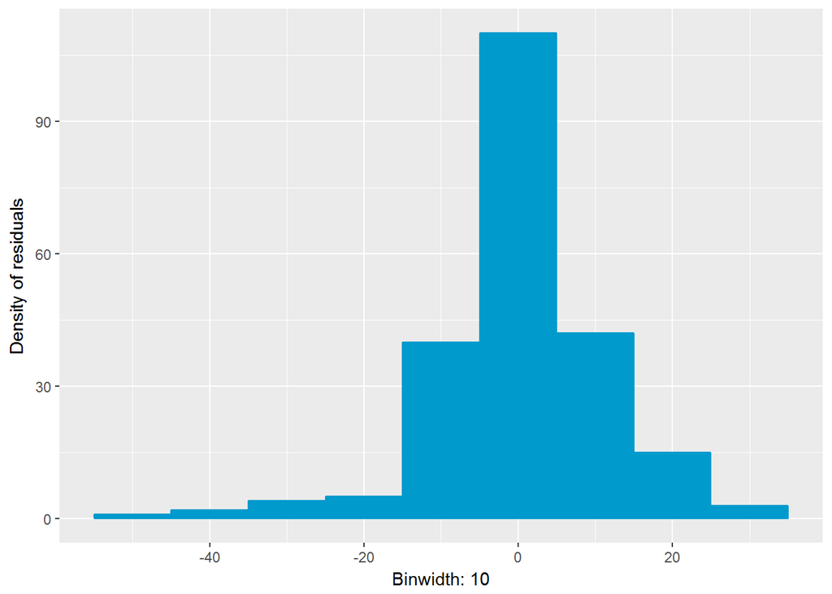

```r
# RESIDUALS
telco$residreg1 <- resid(reg1)
ggplot(telco, aes(x = residreg1)) + geom_histogram(stat = "bin", binwidth=10, fill="deepskyblue3", colour="deepskyblue3") +labs(x="Binwidth: 10", y="Density of residuals")
```

```r
summary(telco$residreg1)
```

```
##    Min. 1st Qu.  Median    Mean 3rd Qu.    Max.
## -47.920  -4.740   0.195   0.000   5.817  27.700
```

```r
basicStats(telco$residreg1)
```

```
##             X..telco.residreg1
## nobs                222.000000
## NAs                   0.000000
## Minimum             -47.916612
## Maximum              27.703330
## 1. Quartile          -4.740266
## 3. Quartile           5.816840
## Mean                  0.000000
## Median                0.194968
## Sum                   0.000000
## SE Mean               0.748256
## LCL Mean             -1.474630
## UCL Mean              1.474630
## Variance            124.294912
## Stdev                11.148763
## Skewness             -0.609033
## Kurtosis              2.091794
```

## Exploring Landline Data

As the expected internet users was very different with the landline control variable, we explored these observations separately. The residuals for this data are significant with a variance of 85.5 and its regression on lngdppc has a wide CI of 7.75 to 9.51, so we can drop landline from future observations [see Appendix].

## Similarities Between Internet and Mobile Penetration

As suspected previously, the slope coefficients on internet and mobile are very similar:

## Moving on to Causality

We know now that there is a correlation of higher modern telecommunications (internet and mobile) with higher GDP per capita, but still need to uncover causality and its direction. Is telecommunication driving GDP growth, or is this latter bringing higher internet penetration? To uncover it we’ll proceed with the following hypothesis:

- we define 1995 to 2005 the “investment period of internet communications” and we’ll uncover the average growth rate of subscribers (it’s indifferent whether governements, companies or individuals invested in growth)
- we are going to split countries above and below the average growth rate
- we define 2005 to 2015 the “GDP growth period” uncovering the average GDP growth rate and split split countries above and below it
- we are going to explore the relationship of internet investments and the upcoming GDP growth rate

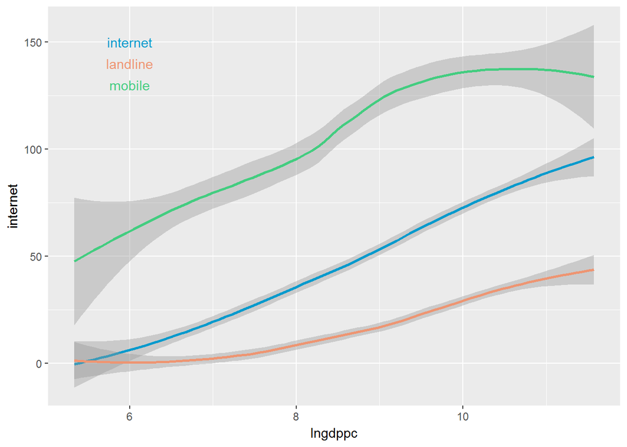

```r
# EXPLORING INTERNET, LANDLINE AND MOBILE
ggplot(telco) +
  geom_smooth(aes(lngdppc, internet), method = "loess", colour = "deepskyblue3", se=T) +
  annotate("text", x = 6, y = 150, label = "internet", colour = "deepskyblue3") +
  geom_smooth(aes(lngdppc, landline), method = "loess", colour = "lightsalmon2", se=T) +
  annotate("text", x = 6, y = 140, label = "landline", colour = "lightsalmon2") +
  geom_smooth(aes(lngdppc, mobile), method = "loess", colour = "seagreen3", se=T) +
  annotate("text", x = 6, y = 130, label = "mobile", colour = "seagreen3")
```

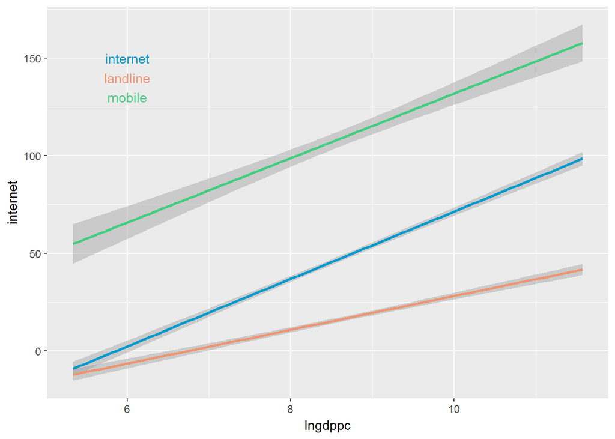

```r
ggplot(telco) +
  geom_smooth(aes(lngdppc, internet), method = "lm", colour = "deepskyblue3", se=T) +
  annotate("text", x = 6, y = 150, label = "internet", colour = "deepskyblue3") +
  geom_smooth(aes(lngdppc, landline), method = "lm", colour = "lightsalmon2", se=T) +
  annotate("text", x = 6, y = 140, label = "landline", colour = "lightsalmon2") +
  geom_smooth(aes(lngdppc, mobile), method = "lm", colour = "seagreen3", se=T) +
  annotate("text", x = 6, y = 130, label = "mobile", colour = "seagreen3")
```

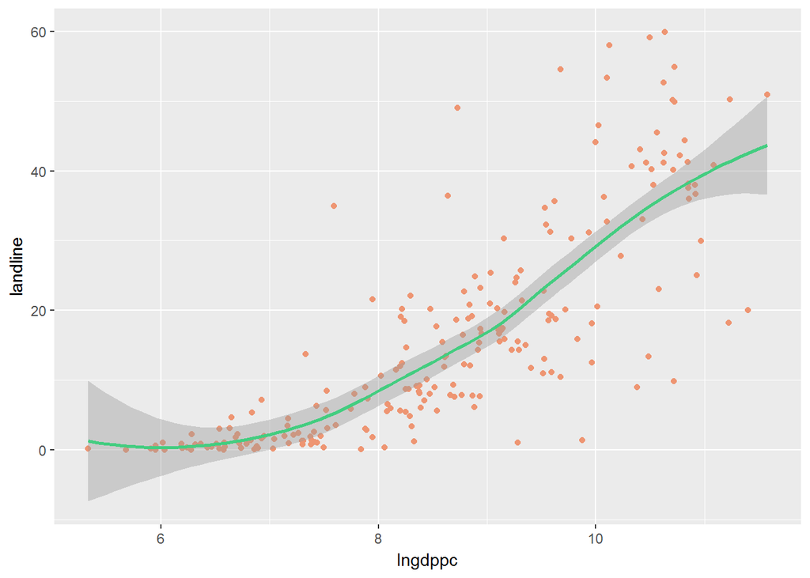

```r
# EXPLORING LANDLINE CORRELATIONS
ggplot(data = telco, aes(x=lngdppc, y=landline)) +
  geom_point(size=1.5, colour="lightsalmon2") +
  geom_smooth(method="loess", colour="seagreen3", se=T)
```

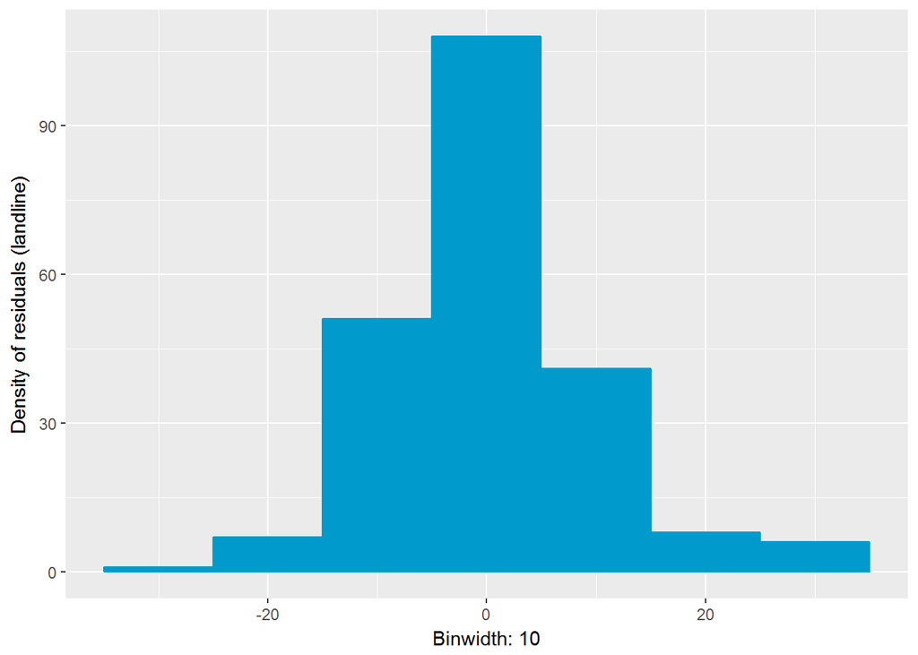

```r
regland1 <- lm(landline ~ lngdppc, data = telco)
telco$residregland1 <- resid(regland1)
ggplot(telco, aes(x = residregland1)) + geom_histogram(stat = "bin", binwidth=10, fill="deepskyblue3", colour="deepskyblue3") +labs(x="Binwidth: 10", y="Density of residuals (landline)")
```

```r
summary(telco$residregland1)
```

```
##     Min.  1st Qu.   Median     Mean  3rd Qu.     Max.
## -25.6400  -5.3110  -0.7927   0.0000   4.9480  31.9000
```

```r
basicStats(telco$residregland1)
```

```
##             X..telco.residregland1
## nobs                    222.000000
## NAs                       0.000000
## Minimum                 -25.637364
## Maximum                  31.897591
## 1. Quartile              -5.311386
## 3. Quartile               4.947605
## Mean                      0.000000
## Median                   -0.792660
## Sum                       0.000000
## SE Mean                   0.620791
## LCL Mean                 -1.223428
## UCL Mean                  1.223428
## Variance                 85.554769
## Stdev                     9.249582
## Skewness                  0.583512
## Kurtosis                  1.654316
```

```r
stargazer(list(regland1), digits = 2, out = "regressions_landline_1.html")
```

```
##
## % Table created by stargazer v.5.2 by Marek Hlavac, Harvard University. E-mail: hlavac at fas.harvard.edu
## % Date and time: Cs, febr. 02, 2017 - 21:44:23
## \begin{table}[!htbp] \centering
##   \caption{}
##   \label{}
## \begin{tabular}{@{\extracolsep{5pt}}lc}
## \\[-1.8ex]\hline
## \hline \\[-1.8ex]
##  & \multicolumn{1}{c}{\textit{Dependent variable:}} \\
## \cline{2-2}
## \\[-1.8ex] & landline \\
## \hline \\[-1.8ex]
##  lngdppc & 8.63$^{***}$ \\
##   & (0.44) \\
##   & \\
##  Constant & $-$58.16$^{***}$ \\
##   & (3.79) \\
##   & \\
## \hline \\[-1.8ex]
## Observations & 222 \\
## R$^{2}$ & 0.64 \\
## Adjusted R$^{2}$ & 0.64 \\
## Residual Std. Error & 9.27 (df = 220) \\
## F Statistic & 392.34$^{***}$ (df = 1; 220) \\
## \hline
## \hline \\[-1.8ex]
## \textit{Note:}  & \multicolumn{1}{r}{$^{*}$p$<$0.1; $^{**}$p$<$0.05; $^{***}$p$<$0.01} \\
## \end{tabular}
## \end{table}
```

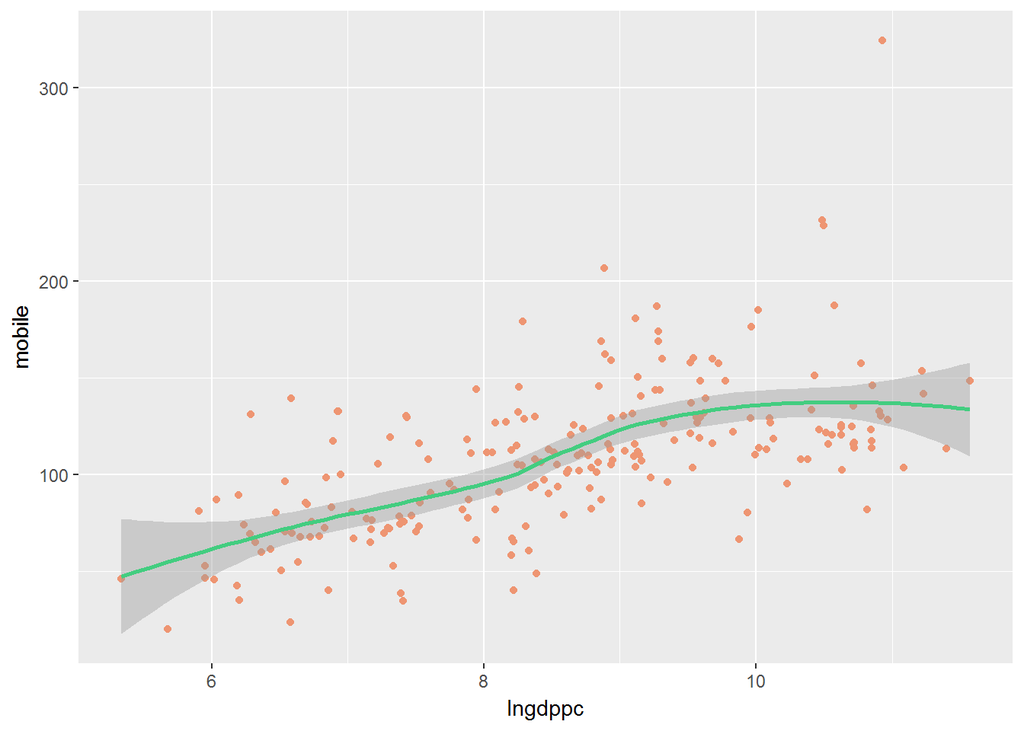

```r
# EXPLORING MOBILE CORRELATIONS
ggplot(data = telco, aes(x=lngdppc, y=mobile)) +
  geom_point(size=1.5, colour="lightsalmon2") +
  geom_smooth(method="loess", colour="seagreen3", se=T)
```

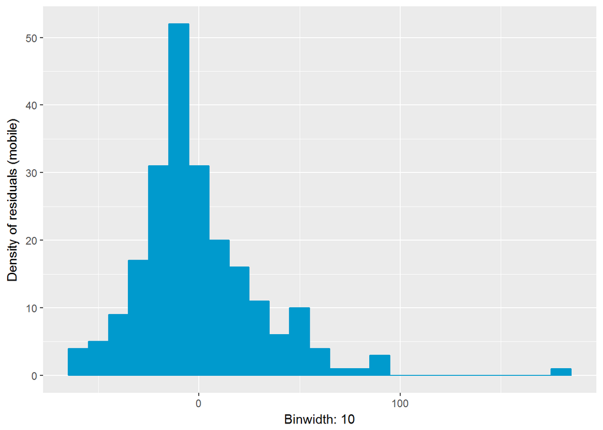

```r
regmob1 <- lm(mobile ~ lngdppc, data = telco)
telco$residregmob1 <- resid(regmob1)
ggplot(telco, aes(x = residregmob1)) + geom_histogram(stat = "bin", binwidth=10, fill="deepskyblue3", colour="deepskyblue3") +labs(x="Binwidth: 10", y="Density of residuals (mobile)")
```

```r
summary(telco$residregmob1)
```

```
##    Min. 1st Qu.  Median    Mean 3rd Qu.    Max.
## -63.410 -17.930  -6.533   0.000  14.400 177.300
```

```r
basicStats(telco$residregmob1)
```

```
##             X..telco.residregmob1
## nobs                   222.000000
## NAs                      0.000000
## Minimum                -63.410762
## Maximum                177.271134
## 1. Quartile            -17.930329
## 3. Quartile             14.400550
## Mean                     0.000000
## Median                  -6.532503
## Sum                      0.000000
## SE Mean                  2.062868
## LCL Mean                -4.065410
## UCL Mean                 4.065410
## Variance               944.704243
## Stdev                   30.736041
## Skewness                 1.347980
## Kurtosis                 4.705196
```

```r
stargazer(list(reg1, reg3, regmob1), digits = 2, out = "regressions_mobile_1.html")
```

```
##
## % Table created by stargazer v.5.2 by Marek Hlavac, Harvard University. E-mail: hlavac at fas.harvard.edu
## % Date and time: Cs, febr. 02, 2017 - 21:44:24
## \begin{table}[!htbp] \centering
##   \caption{}
##   \label{}
## \begin{tabular}{@{\extracolsep{5pt}}lccc}
## \\[-1.8ex]\hline
## \hline \\[-1.8ex]
##  & \multicolumn{3}{c}{\textit{Dependent variable:}} \\
## \cline{2-4}
## \\[-1.8ex] & \multicolumn{2}{c}{internet} & mobile \\
## \\[-1.8ex] & (1) & (2) & (3)\\
## \hline \\[-1.8ex]
##  lngdppc & 17.25$^{***}$ & 16.63$^{***}$ & 16.50$^{***}$ \\
##   & (0.53) & (0.66) & (1.45) \\
##   & & & \\
##  mobile &  & 0.04 &  \\
##   &  & (0.02) &  \\
##   & & & \\
##  Constant & $-$101.08$^{***}$ & $-$99.84$^{***}$ & $-$33.17$^{***}$ \\
##   & (4.57) & (4.62) & (12.59) \\
##   & & & \\
## \hline \\[-1.8ex]
## Observations & 222 & 222 & 222 \\
## R$^{2}$ & 0.83 & 0.83 & 0.37 \\
## Adjusted R$^{2}$ & 0.83 & 0.83 & 0.37 \\
## Residual Std. Error & 11.17 (df = 220) & 11.14 (df = 219) & 30.81 (df = 220) \\
## F Statistic & 1,078.82$^{***}$ (df = 1; 220) & 543.85$^{***}$ (df = 2; 219) & 129.88$^{***}$ (df = 1; 220) \\
## \hline
## \hline \\[-1.8ex]
## \textit{Note:}  & \multicolumn{3}{r}{$^{*}$p$<$0.1; $^{**}$p$<$0.05; $^{***}$p$<$0.01} \\
## \end{tabular}
## \end{table}
```

## Exploring Internet Investments

- 1995’s mean: 0.92 (stdev: 2.04)
- 2005’s mean: 19.92 (stdev: 22.26)
- growth mean (2005-1995): 23.97 (stdev: 22.15)

The distribution of internet penetration growth is skewed to the right with a mean at 23.97.

We will use this mean as the standard for internet investments: countries having an internet penetration growth less than 23.97% will be considered low investors in modern digital communications, those above as high investors. We expect that GDP growth will be higher from 2005 to 2015 for countries considered high investors in digital communications. 64 countries can be considered high investors (reached a penetration of 23.97% after 10 years), 104 countries low investors in internet penetration.

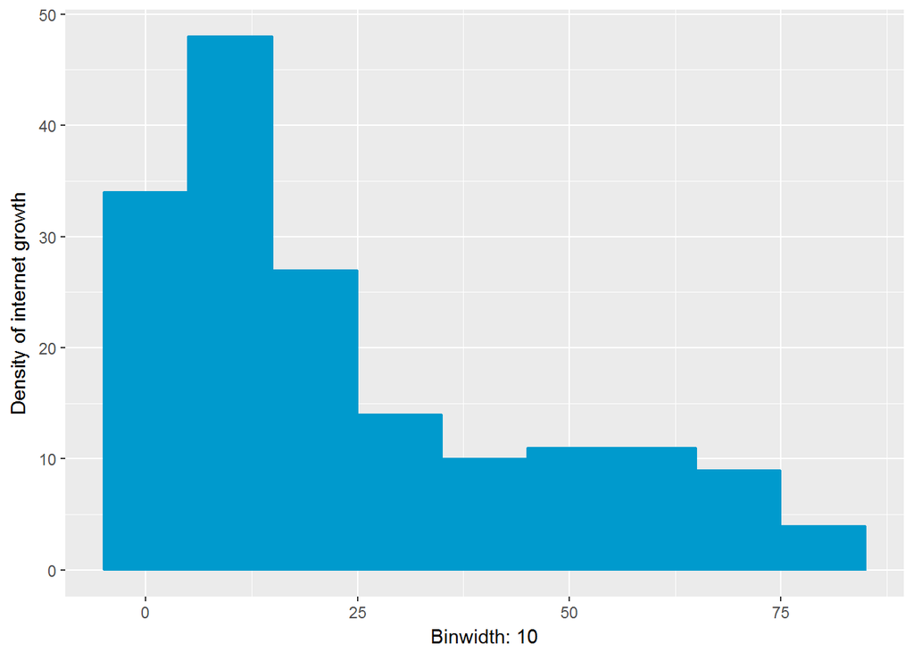

```r
# INTERNET INVESTMENTS
names(dataset)[names(dataset) == "X1995..YR1995."] <- "1995"
names(dataset)[names(dataset) == "X2005..YR2005."] <- "2005"
internetinvest <- subset(dataset, select = c("country", "1995", "2005"), series == "Internet users (per 100 people)")
internetinvest$"1995" <- as.numeric(as.character(internetinvest$"1995"))
internetinvest$"2005" <- as.numeric(as.character(internetinvest$"2005"))
internetinvest$invest <- internetinvest$"2005" - internetinvest$"1995"
ggplot(internetinvest, aes(x = invest)) + geom_histogram(stat = "bin", binwidth=10, fill="deepskyblue3", colour="deepskyblue3") +labs(x="Binwidth: 10", y="Density of internet growth")
```

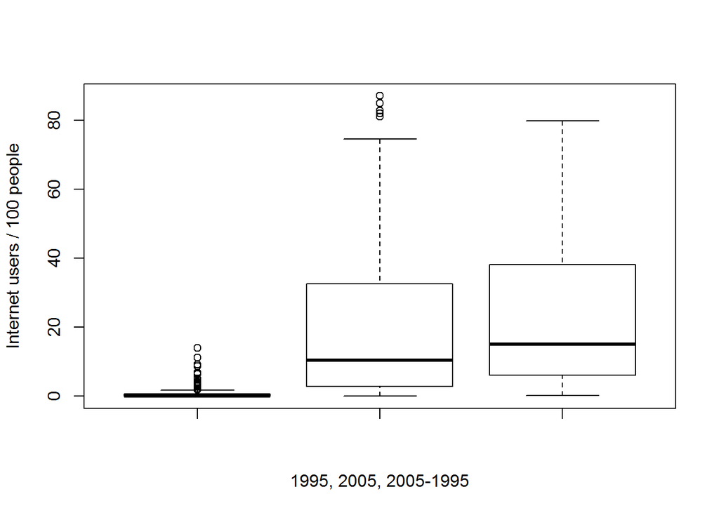

```r
boxplot(internetinvest$"1995", internetinvest$"2005", internetinvest$invest, xlab = "1995, 2005, 2005-1995", ylab = "Internet users / 100 people")
```

```r
basicStats(internetinvest$"1995")
```

```
##             X..internetinvest.1995
## nobs                    264.000000
## NAs                      93.000000
## Minimum                   0.000000
## Maximum                  13.900304
## 1. Quartile               0.011247
## 3. Quartile               0.713551
## Mean                      0.926483
## Median                    0.081691
## Sum                     158.428619
## SE Mean                   0.156314
## LCL Mean                  0.617917
## UCL Mean                  1.235049
## Variance                  4.178206
## Stdev                     2.044066
## Skewness                  3.517690
## Kurtosis                 14.517798
```

```r
basicStats(internetinvest$"2005")
```

```
##             X..internetinvest.2005
## nobs                    264.000000
## NAs                      20.000000
## Minimum                   0.000000
## Maximum                  87.000000
## 1. Quartile               2.889745
## 3. Quartile              32.471761
## Mean                     19.919847
## Median                   10.336901
## Sum                    4860.442699
## SE Mean                   1.425213
## LCL Mean                 17.112500
## UCL Mean                 22.727195
## Variance                495.620396
## Stdev                    22.262533
## Skewness                  1.244182
## Kurtosis                  0.471738
```

```r
basicStats(internetinvest$invest)
```

```
##             X..internetinvest.invest
## nobs                      264.000000
## NAs                        96.000000
## Minimum                     0.215392
## Maximum                    79.731976
## 1. Quartile                 6.012147
## 3. Quartile                38.036722
## Mean                       23.970636
## Median                     15.079628
## Sum                      4027.066817
## SE Mean                     1.709101
## LCL Mean                   20.596407
## UCL Mean                   27.344865
## Variance                  490.732500
## Stdev                      22.152483
## Skewness                    0.893499
## Kurtosis                   -0.454689
```

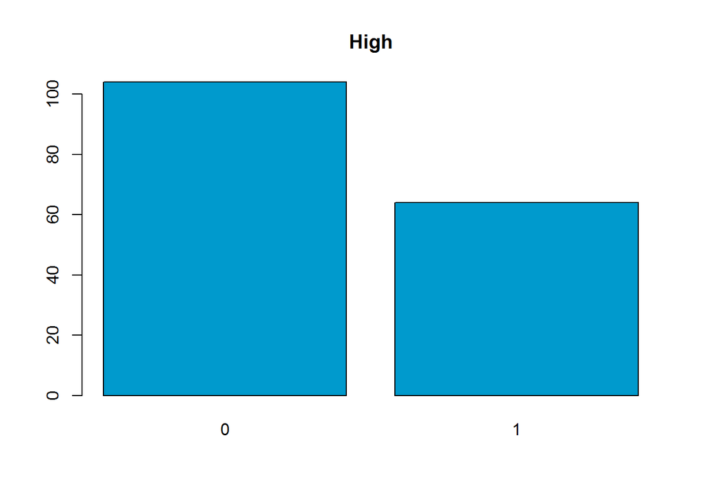

```
## internetinvest$high
##       Frequency Percent Valid Percent
## 0           104   39.39          61.9
## 1            64   24.24          38.1
## NA's         96   36.36
## Total       264  100.00         100.0
```

```r
# GROUPS OF HIGH AND LOW INTERNET INVESTORS
internetinvest$high[internetinvest$invest > 23.97] <- 1
internetinvest$high[internetinvest$invest < 23.97] <- 0
internetinvest$low[internetinvest$invest < 23.97] <- 1
internetinvest$low[internetinvest$invest > 23.97] <- 0
freq(internetinvest$high, col="deepskyblue3", main="High")
```

```r
basicStats(internetinvest$high)
```

```
##             X..internetinvest.high
## nobs                    264.000000
## NAs                      96.000000
## Minimum                   0.000000
## Maximum                   1.000000
## 1. Quartile               0.000000
## 3. Quartile               1.000000
## Mean                      0.380952
## Median                    0.000000
## Sum                      64.000000
## SE Mean                   0.037578
## LCL Mean                  0.306762
## UCL Mean                  0.455142
## Variance                  0.237240
## Stdev                     0.487073
## Skewness                  0.485919
## Kurtosis                 -1.774338
```

```r
basicStats(internetinvest$low)
```

```
##             X..internetinvest.low
## nobs                   264.000000
## NAs                     96.000000
## Minimum                  0.000000
## Maximum                  1.000000
## 1. Quartile              0.000000
## 3. Quartile              1.000000
## Mean                     0.619048
## Median                   1.000000
## Sum                    104.000000
## SE Mean                  0.037578
## LCL Mean                 0.544858
## UCL Mean                 0.693238
## Variance                 0.237240
## Stdev                    0.487073
## Skewness                -0.485919
## Kurtosis                -1.774338
```

## Trends in GDP

We defined 2005 to 2015 as the fruition period after investing into internet communications (nevertheless, further growth of penetration is expected, but not considered in this exercise). The growth in GDP is showing small numbers, with significant outliers so we’ll explore our final comparison with the natural log of GDP growth from 2005 to 2015.

The distribution of GDP growth after our pre-defined internet communications investment period is skewed to the left with a mean of 6.74. Log GDPpc of 6.74 will be the divider between countries with high and low GDP growth. 111 countries can be considered with GDP per capita growth above the average of 6.74 log, 92 below.

## GDP Growth After Above Average Internet Penetration

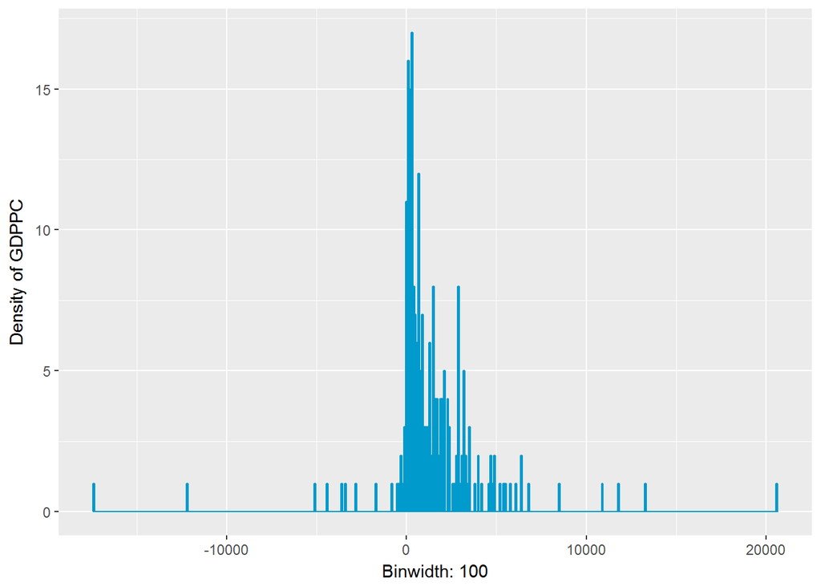

```r
# GDPPC GROWTH
gdppcgrowth <- subset(dataset, select = c("country", "2005", "2015"), series == "GDP per capita (constant 2010 US$)")
gdppcgrowth$"2005" <- as.numeric(as.character(gdppcgrowth$"2005"))
gdppcgrowth$"2015" <- as.numeric(as.character(gdppcgrowth$"2015"))
gdppcgrowth$growth <- gdppcgrowth$"2015" - gdppcgrowth$"2005"
ggplot(gdppcgrowth, aes(x = growth)) + geom_histogram(stat = "bin", binwidth=100, fill="deepskyblue3", colour="deepskyblue3") +labs(x="Binwidth: 100", y="Density of GDPPC")
```

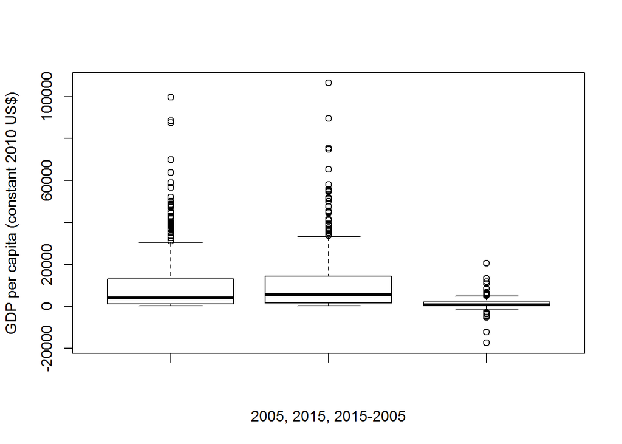

```r
boxplot(gdppcgrowth$"2005", gdppcgrowth$"2015", gdppcgrowth$growth, xlab = "2005, 2015, 2015-2005", ylab = "GDP per capita (constant 2010 US$)")
```

```r
basicStats(gdppcgrowth$"2005")
```

```
##             X..gdppcgrowth.2005
## nobs               2.640000e+02
## NAs                2.600000e+01
## Minimum            2.050720e+02
## Maximum            9.962605e+04
## 1. Quartile        1.233477e+03
## 3. Quartile        1.284816e+04
## Mean               1.193296e+04
## Median             3.956738e+03
## Sum                2.840045e+06
## SE Mean            1.139593e+03
## LCL Mean           9.687937e+03
## UCL Mean           1.417799e+04
## Variance           3.090838e+08
## Stdev              1.758078e+04
## Skewness           2.201008e+00
## Kurtosis           5.121420e+00
```

```r
basicStats(gdppcgrowth$"2015")
```

```
##             X..gdppcgrowth.2015
## nobs               2.640000e+02
## NAs                3.700000e+01
## Minimum            2.067114e+02
## Maximum            1.064086e+05
## 1. Quartile        1.659988e+03
## 3. Quartile        1.441897e+04
## Mean               1.282870e+04
## Median             5.499728e+03
## Sum                2.912114e+06
## SE Mean            1.176368e+03
## LCL Mean           1.051065e+04
## UCL Mean           1.514675e+04
## Variance           3.141320e+08
## Stdev              1.772377e+04
## Skewness           2.216307e+00
## Kurtosis           5.401707e+00
```

```r
basicStats(gdppcgrowth$growth)
```

```
##             X..gdppcgrowth.growth
## nobs                 2.640000e+02
## NAs                  3.900000e+01
## Minimum             -1.735047e+04
## Maximum              2.056002e+04
## 1. Quartile          2.261579e+02
## 3. Quartile          2.137942e+03
## Mean                 1.394700e+03
## Median               8.107891e+02
## Sum                  3.138075e+05
## SE Mean              1.963275e+02
## LCL Mean             1.007815e+03
## UCL Mean             1.781585e+03
## Variance             8.672507e+06
## Stdev                2.944912e+03
## Skewness             3.830550e-01
## Kurtosis             1.740487e+01
```

```r
gdppcgrowth$lngdppcgrowth <- log(gdppcgrowth$growth)
```

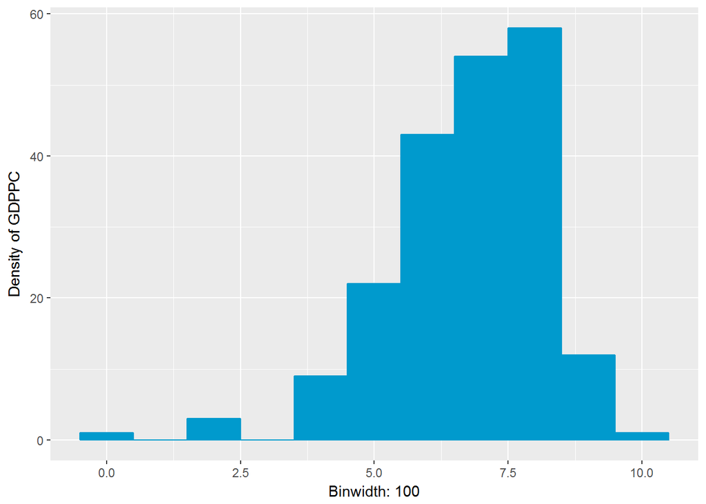

```r
ggplot(gdppcgrowth, aes(x = lngdppcgrowth)) + geom_histogram(stat = "bin", binwidth=1, fill="deepskyblue3", colour="deepskyblue3") +labs(x="Binwidth: 100", y="Density of GDPPC")
```

```r
basicStats(gdppcgrowth$lngdppcgrowth)
```

```
##             X..gdppcgrowth.lngdppcgrowth
## nobs                          264.000000
## NAs                            61.000000
## Minimum                         0.494346
## Maximum                         9.931104
## 1. Quartile                     5.839332
## 3. Quartile                     7.763458
## Mean                            6.741727
## Median                          6.922152
## Sum                          1368.570604
## SE Mean                         0.100895
## LCL Mean                        6.542785
## UCL Mean                        6.940669
## Variance                        2.066484
## Stdev                           1.437527
## Skewness                       -0.866501
## Kurtosis                        1.448987
```

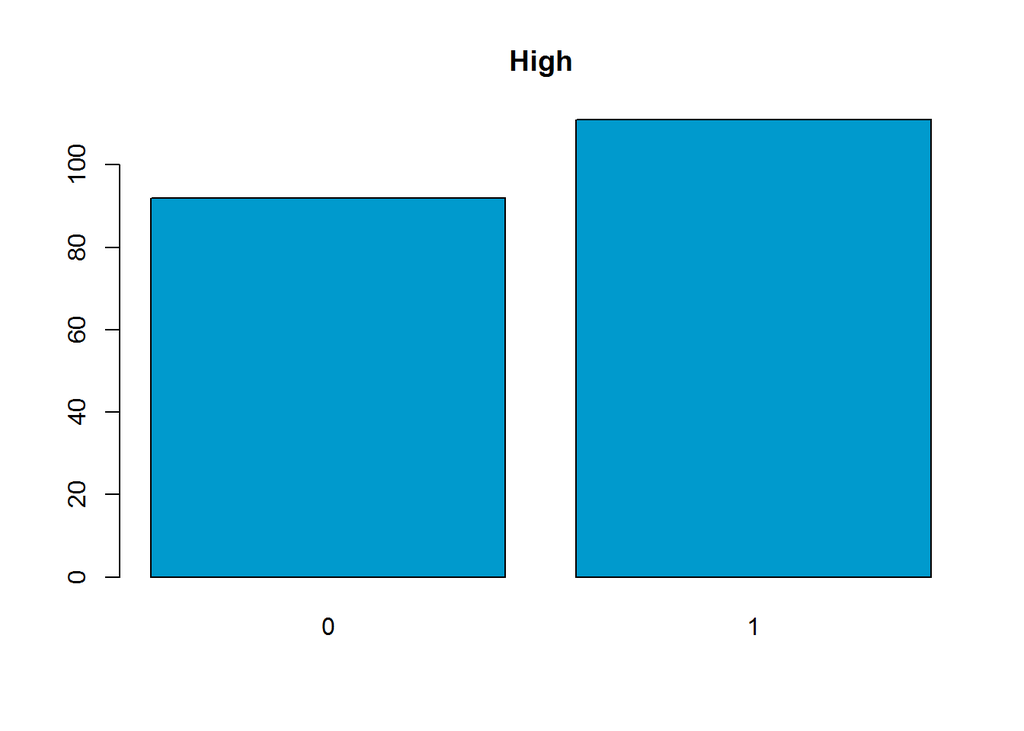

```
## gdppcgrowth$high
##       Frequency Percent Valid Percent
## 0            92   34.85         45.32
## 1           111   42.05         54.68
## NA's         61   23.11
## Total       264  100.00        100.00
```

```r
# GROUPS OF HIGH AND LOW GDPGROWTH
gdppcgrowth$high[gdppcgrowth$lngdppcgrowth > 6.74] <- 1
gdppcgrowth$high[gdppcgrowth$lngdppcgrowth < 6.74] <- 0
gdppcgrowth$low[gdppcgrowth$lngdppcgrowth < 6.74] <- 1
gdppcgrowth$low[gdppcgrowth$lngdppcgrowth > 6.74] <- 0
freq(gdppcgrowth$high, col="deepskyblue3", main="High")
```

```r
basicStats(gdppcgrowth$high)
```

```
##             X..gdppcgrowth.high
## nobs                 264.000000
## NAs                   61.000000
## Minimum                0.000000
## Maximum                1.000000
## 1. Quartile            0.000000
## 3. Quartile            1.000000
## Mean                   0.546798
## Median                 1.000000
## Sum                  111.000000
## SE Mean                0.035025
## LCL Mean               0.477736
## UCL Mean               0.615860
## Variance               0.249037
## Stdev                  0.499036
## Skewness              -0.186630
## Kurtosis              -1.974825
```

```r
basicStats(gdppcgrowth$low)
```

```
##             X..gdppcgrowth.low
## nobs                264.000000
## NAs                  61.000000
## Minimum               0.000000
## Maximum               1.000000
## 1. Quartile           0.000000
## 3. Quartile           1.000000
## Mean                  0.453202
## Median                0.000000
## Sum                  92.000000
## SE Mean               0.035025
## LCL Mean              0.384140
## UCL Mean              0.522264
## Variance              0.249037
## Stdev                 0.499036
## Skewness              0.186630
## Kurtosis             -1.974825
```

```r
# CROSSTABLES
CrossTable(gdppcgrowth$high, internetinvest$high)
```

```
##
##
##    Cell Contents
## |-------------------------|
## |                       N |
## | Chi-square contribution |
## |           N / Row Total |
## |           N / Col Total |
## |         N / Table Total |
## |-------------------------|
##
##
## Total Observations in Table:  138
##
##
##                  | internetinvest$high
## gdppcgrowth$high |         0 |         1 | Row Total |
## -----------------|-----------|-----------|-----------|
##                0 |        45 |         3 |        48 |
##                  |     5.281 |    10.562 |           |
##                  |     0.938 |     0.062 |     0.348 |
##                  |     0.489 |     0.065 |           |
##                  |     0.326 |     0.022 |           |
## -----------------|-----------|-----------|-----------|
##                1 |        47 |        43 |        90 |
##                  |     2.817 |     5.633 |           |
##                  |     0.522 |     0.478 |     0.652 |
##                  |     0.511 |     0.935 |           |
##                  |     0.341 |     0.312 |           |
## -----------------|-----------|-----------|-----------|
##     Column Total |        92 |        46 |       138 |
##                  |     0.667 |     0.333 |           |
## -----------------|-----------|-----------|-----------|
##
##
```

```r
CrossTable(gdppcgrowth$high, internetinvest$low)
```

```
##
##
##    Cell Contents
## |-------------------------|
## |                       N |
## | Chi-square contribution |
## |           N / Row Total |
## |           N / Col Total |
## |         N / Table Total |
## |-------------------------|
##
##
## Total Observations in Table:  138
##
##
##                  | internetinvest$low
## gdppcgrowth$high |         0 |         1 | Row Total |
## -----------------|-----------|-----------|-----------|
##                0 |         3 |        45 |        48 |
##                  |    10.562 |     5.281 |           |
##                  |     0.062 |     0.938 |     0.348 |
##                  |     0.065 |     0.489 |           |
##                  |     0.022 |     0.326 |           |
## -----------------|-----------|-----------|-----------|
##                1 |        43 |        47 |        90 |
##                  |     5.633 |     2.817 |           |
##                  |     0.478 |     0.522 |     0.652 |
##                  |     0.935 |     0.511 |           |
##                  |     0.312 |     0.341 |           |
## -----------------|-----------|-----------|-----------|
##     Column Total |        46 |        92 |       138 |
##                  |     0.333 |     0.667 |           |
## -----------------|-----------|-----------|-----------|
##
##
```

```r
CrossTable(gdppcgrowth$low, internetinvest$high)
```

```
##
##
##    Cell Contents
## |-------------------------|
## |                       N |
## | Chi-square contribution |
## |           N / Row Total |
## |           N / Col Total |
## |         N / Table Total |
## |-------------------------|
##
##
## Total Observations in Table:  138
##
##
##                 | internetinvest$high
## gdppcgrowth$low |         0 |         1 | Row Total |
## ----------------|-----------|-----------|-----------|
##               0 |        47 |        43 |        90 |
##                 |     2.817 |     5.633 |           |
##                 |     0.522 |     0.478 |     0.652 |
##                 |     0.511 |     0.935 |           |
##                 |     0.341 |     0.312 |           |
## ----------------|-----------|-----------|-----------|
##               1 |        45 |         3 |        48 |
##                 |     5.281 |    10.562 |           |
##                 |     0.938 |     0.062 |     0.348 |
##                 |     0.489 |     0.065 |           |
##                 |     0.326 |     0.022 |           |
## ----------------|-----------|-----------|-----------|
##    Column Total |        92 |        46 |       138 |
##                 |     0.667 |     0.333 |           |
## ----------------|-----------|-----------|-----------|
##
##
```

```r
CrossTable(gdppcgrowth$low, internetinvest$low)
```

```
##
##
##    Cell Contents
## |-------------------------|
## |                       N |
## | Chi-square contribution |
## |           N / Row Total |
## |           N / Col Total |
## |         N / Table Total |
## |-------------------------|
##
##
## Total Observations in Table:  138
##
##
##                 | internetinvest$low
## gdppcgrowth$low |         0 |         1 | Row Total |
## ----------------|-----------|-----------|-----------|
##               0 |        43 |        47 |        90 |
##                 |     5.633 |     2.817 |           |
##                 |     0.478 |     0.522 |     0.652 |
##                 |     0.935 |     0.511 |           |
##                 |     0.312 |     0.341 |           |
## ----------------|-----------|-----------|-----------|
##               1 |         3 |        45 |        48 |
##                 |    10.562 |     5.281 |           |
##                 |     0.062 |     0.938 |     0.348 |
##                 |     0.065 |     0.489 |           |
##                 |     0.022 |     0.326 |           |
## ----------------|-----------|-----------|-----------|
##    Column Total |        46 |        92 |       138 |
##                 |     0.333 |     0.667 |           |
## ----------------|-----------|-----------|-----------|
##
##
```

## Conclusion

We come back to our initial question: how the performance of countries relates to their internet adoption? We identified the performance of the countries by GDP per capita and defined the performance review years from 2005 to 2015. We defined internet adoption as the growth rate of internet penetration between 1995 and 2005, the initial years when digital communication started.